# Webtoons Project

Tonia Wu

# Introduction

## What are Webtoons?

Webtoons are a type of digital comic from South Korea designed for vertical scrolling on computers and mobile devices. They are often published in full color and may feature music and animations. For the purposes of this project, we will be specifically looking at the comics on Naver Webtoon.

[figure not shown]

Webtoons Originals, which for the sake of brevity we will refer to as “webtoons,” first start on the Discover section of the platform. Anyone can upload to Discover; once a comic is discovered by Webtoon’s editors and the artist agrees to a contract, it will move to the Originals.

## Webtoon Styles

This project aims to find a connection between a webtoon’s art style and variables such as its performance (such as likes and views), genre, and upload schedule.

To give some background on the various art styles creators use, I’ve divided each webtoon into one of several styles:

## Standard

[figure not shown]

Wished You Were Dead

## Simplified Cartoon

[figure not shown]

Supersonic Girl

The simplified cartoon/comic style covers art styles that mimic that of TV animation. They often simplify their characters into highly readable shapes and use a wider variety of line weights than the standard style does. Many also include brighter and wackier color palettes, as well as textured brushes.

## Realistic Standard

[figure not shown]

Covenant

This style is in between the standard and American styles in that it generally includes fingernails, nostrils, blunter jaws, teeth, gums, etc. There are more variations in nose shapes and a tendency to have smaller, more proportionate eyes.

## American

[figure not shown]

(from left) The Strange Tales of Oscar Zahn, Cyko-KO, GOSU

This style gives its characters stronger jaws, strong shading, and intense black shadows. It doesn’t shy away from showing wrinkles, fingernails, and other details usually absent from standard styles. Many also use textured brushes, as in the first example, or thick, tapered, and vary line weights and a desaturated blue to highlight black hair, as in the second.

Overall, the clearest market of this style is heavy employment of black. The last example is not your classic Western superhero comic, but I’ve included it in this style because it employs its conventions regardless. *Note that my use of ‘American’ does not indicate the country of origin.*

## Korean Realism

[figure not shown]

[figure not shown]

This style differs from the realistic standard style in that its realism focus often comes from its volumetric skin shading (often done with an airbrush or multiple low opacity brush strokes). The skin shading usually highlights bone structure, lips (including the men!), and the body in a “fleshy” way that appeals to an East Asian audience. Like the standard style, you will often see a delicate face on a muscular body.

With Korean realism, if there is no volumetric skin shading, there will still be a clear emphasis on or intense effort put in illustrating everyone in an attractive way. For that reason, I nearly named this style “Korean idealism” (but did not because it brings a new set of connotations.) I have kept “Korean” in the style name because we are dealing with a medium that originated in Korea. As far as the other major East Asian countries go, in general, the “Japanese” and “Chinese” styles are more in line with the standard category. For the sake of this project I will not splinter the standard style any further.

# Loading Data

For this project, we will be working with data from the English platform of Naver Webtoon. The file is from Kaggle: https://www.kaggle.com/datasets/iridazzle/webtoon-originals-datasets.

Webtoons do not come with information on their art style or their author’s country of origin, so I had to manually input them.

The raw file contains data on the genre, authors, weekdays uploaded, number of free episodes, subscriber count, views, likes, upload status, and the synopsis:

```r
rawdata <- read.csv('webtoon_originals_en.csv')
```

```r
head(rawdata)
```

|  | title_id | title | style | original.platform | genre | authors | weekdays | length | subscribers | rating | views | likes | status | daily_pass | synopsis |
| --- | --- | --- | --- | --- | --- | --- | --- | --- | --- | --- | --- | --- | --- | --- | --- |
| 1 | 3766 | 100 | realistic standard | Korean | ACTION | Hyeong Eun,Yunyeol Choi | SUNDAY | 13 | 109568 | 9.18 | 827013 | 86431 | ONGOING | FALSE | Armed only with a gun and a frying pan, Hoyoung Cheon must survive Battlegrounds: a battle-royale style game with 100 participants, where there’s only one way to win: kill the 99 other players, all of… |
| 2 | 1217 | 1000 | American | English | ACTION | Chuck Brown,Sanford Greene | THURSDAY | 20 | 104855 | 8.99 | 1444572 | 80168 | COMPLETED | FALSE | Set in a modern world of aliens, warlocks, zombies, and ancient beasts, "1000" follows Dragon Son - a supreme entity who’s abandoned all creation as he struggles to return to his true Dragon form by c… |
| 3 | 1193 | #Blessed | American | English | DRAMA | M. Victoria Robado | FRIDAY | 64 | 423396 | 9.19 | 19989806 | 1720168 | HIATUS | FALSE | Joanna is a mid-twenties office girl who likes social media and watered down coffee. While griping about her love life, she accidentally swiped right on a whole Pantheon of Gods and Goddesses! Looking… |
| 4 | 1971 | #Killstagram | realistic standard | Korean | THRILLER | Ryoung | SATURDAY | 44 | 870587 | 9.32 | 39281698 | 3498815 | HIATUS | FALSE | Remi Do has everything -- she's super pretty, has the best brand sponsorships on social media, and gets 10,000 likes within seconds of posting a selfie. Oh, and she also has a serial-killing stalker f… |
| 5 | 71 | 10th Dimension Boys | cartoon | English | COMEDY | Cutbu | TUESDAY,WEDNESDAY,THURSDAY | 119 | 93215 | 9.34 | 27986110 | 801533 | COMPLETED | FALSE | In another dimension, anything can happen in your daily life. Absurdly funny, the boys from the 10th dimension are up to no good again. |
| 6 | 3235 | 11 of Me | American | Korean | SUPERNATURAL | Jiae Go,Jaeyeong Yeong | MONDAY,TUESDAY,WEDNESDAY,THURSDAY,FRIDAY,SATURDAY,SUNDAY | 7 | 102268 | 8.83 | 1407074 | 195701 | COMPLETED | TRUE | To Gibeom’s surprise, the mechanical calculator he bought working at a junkyard turns out to be a time machine! With the time machine, he sets out to find and bring together his past selves. Currently… |

Before we can proceed, we will need to clean and unstack some of the columns.

# Data Cleaning

Here are the steps I took to prepare the data.

- Cleaning the names

```r
webtoons <- rawdata %>%
  clean_names()
```

- Adding a new variable called `synopsis_length` to quantify the `synopsis`, since I’m curious if it will make an impact

```r
webtoons <- webtoons %>%
  mutate(synopsis_length = str_count(synopsis))
```

- Dropping unhelpful variables, such as `title_id`

```r
webtoons <- webtoons%>%
  select(-c(authors, title_id, synopsis))
```

- Renaming the length column to the more descriptive ‘free_episodes’ to avoid confusion:

```r
webtoons <- webtoons %>%
  rename(free_episodes = length)
```

# Exploratory Data Analysis

Naver first began publishing webtoons in 2004 and started offering English translations of its most popular comics in 2014. Thus, I expect its general audience to skew towards a younger demographic, giving rise to an uneven genre distribution (though I’m sure it’d be uneven regardless, since people obviously have varying tastes). Let’s take a look:

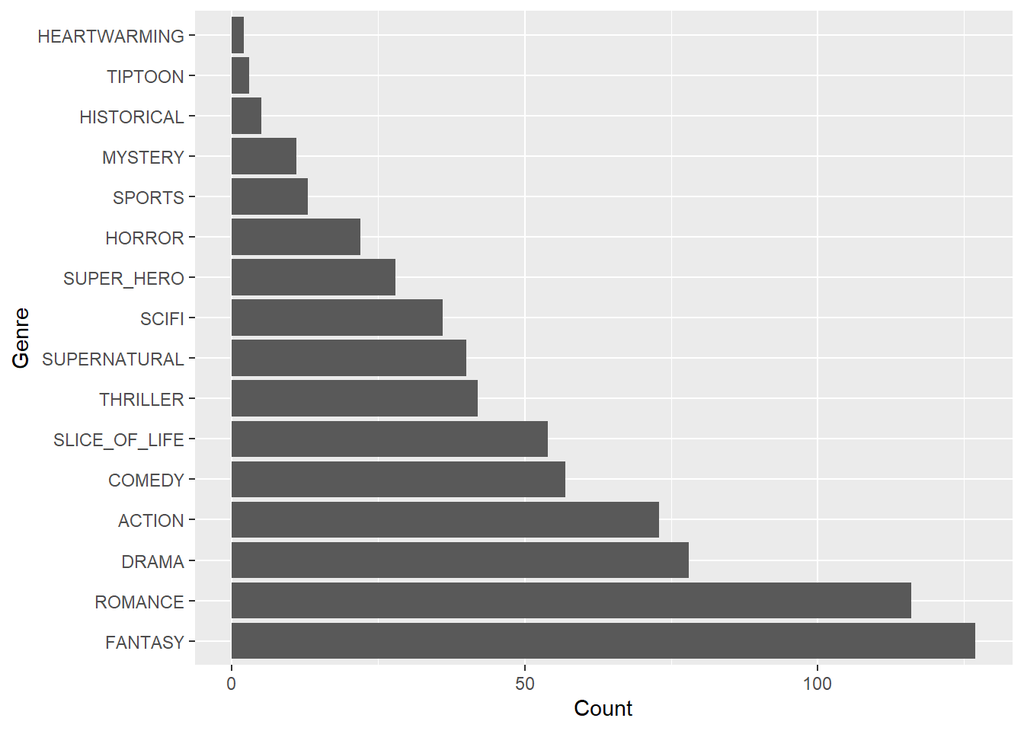

```r
webtoons %>%
  group_by(genre) %>%
  summarise(count = n()) %>%
  ggplot(aes(x = reorder(genre, (-count)), y = count)) +
  geom_bar(stat = 'identity') +
  coord_flip() +
  labs(y = 'Count', x = 'Genre')
```

The two dominating categories, fantasy and romance, have broad appeal. This is not too surprising. We must also remember that a single webtoon may encompass more than one genre.

One of the least popular genres is called a “Tiptoon.” These are informative webtoons that the platform sometimes asks its creators to illustrate, giving tips on subjects such as how to stay healthy during the pandemic and how to edit your webtoon. As they are not a regular fictive comic, we will drop the genre.

```r
webtoons <- subset(webtoons, genre != 'TIPTOON')
```

I also suspect budding authors to look at the synopses of established creators in their genres as inspiration. Let’s see if synopsis lengths are generally similar within their genres.

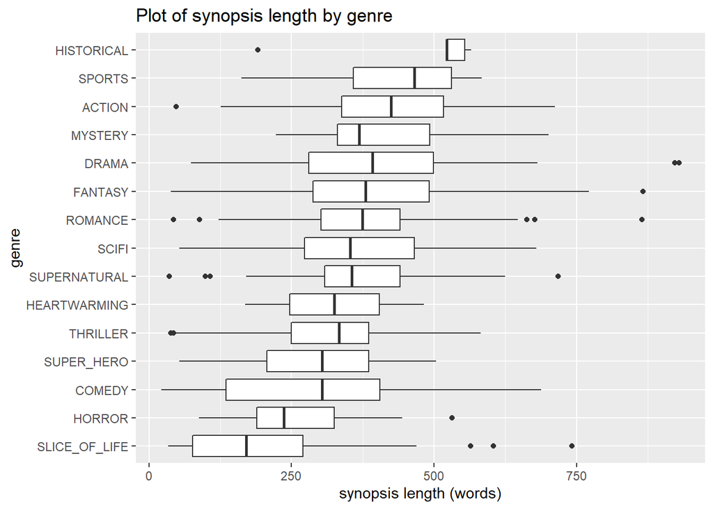

```r
webtoons %>%
  ggplot(aes(x=reorder(genre, synopsis_length), y=synopsis_length)) +
  geom_boxplot() +
  coord_flip() + labs(title = 'Plot of synopsis length by genre',
               y = 'synopsis length (words)',
               x = 'genre')
```

Since we do see increasing fundamental differences in median `synopsis_length`, we will retain it for our models.

Now let’s look at the distribution of our outcome variable, `style`.

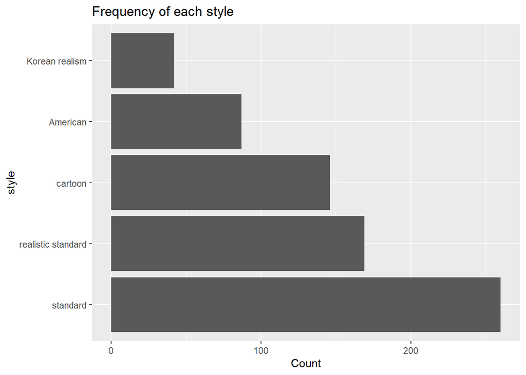

```r
bp2_count <- plyr::count(webtoons$style)

webtoons$style <- factor(webtoons$style,
  levels = bp2_count$x[order(bp2_count$freq, decreasing = TRUE)])

ggplot(data = webtoons, aes(x = style)) +
  geom_bar() +
  coord_flip() +
  labs(title = 'Frequency of each style', y = 'Count', x = 'style')
```

```r
likes_lab <- c('Am', 'r', 'ct', 's', 'Kor')
likes_plot <- ggplot(webtoons, aes(reorder(style, likes), likes)) +
  geom_boxplot(varwidth = TRUE) +
  labs(
    title = "Likes by Style",
    x = "Style"
  ) + coord_trans(x = 'log2', y = 'log2') + scale_x_discrete(labels = likes_lab)

views_lab <- c('Am', 'r', 'ct', 's', 'Kor')
views_plot <- ggplot(webtoons, aes(reorder(style, views), views)) +
  geom_boxplot(varwidth = TRUE) +
  labs(
    title = "Views by Style",
    x = "Style"
  ) + coord_trans(x = 'log2', y = 'log2')  + scale_x_discrete(labels = views_lab)

subs_lab <- c('Am', 'ct', 'r', 's', 'Kor')
subs_plot <- ggplot(webtoons, aes(reorder(style, subscribers), subscribers)) +
  geom_boxplot(varwidth = TRUE) +
  labs(
    title = "Subscribers by Style",
    x = "Style"
  ) + coord_trans(x = 'log2', y = 'log2') + scale_x_discrete(labels = subs_lab)

rating_lab <- c('Am', 'ct', 'r', 'Kor', 's')
rating_plot <- ggplot(webtoons, aes(reorder(style, rating), rating)) +
  geom_boxplot(varwidth = TRUE) +
  labs(
    title = "Rating by Style",
    x = "Style"
  ) + coord_trans(x = 'log2', y = 'log2') +
  scale_x_discrete(labels = rating_lab)
```

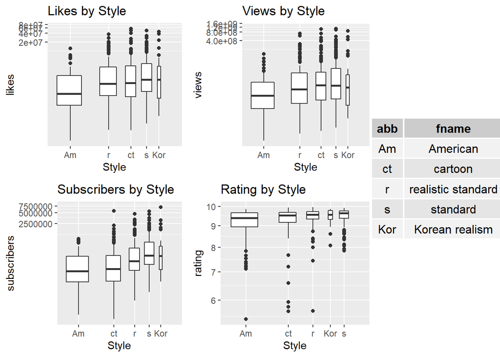

```r
full_name <- data.frame(abb =c('Am','ct','r', 's', 'Kor'),fname = c('American','cartoon','realistic standard', 'standard', 'Korean realism'))


square_plot <- ggarrange(likes_plot, views_plot, subs_plot, rating_plot,
          ncol = 2, nrow = 2) +
  theme(axis.text.x = element_text(angle = 90, hjust = 1))

grid.arrange(square_plot, tableGrob(full_name, rows = NULL), nrow = 1, widths = c(3, 1))
```

Readers may prefer a more Asian style. This should not come as a surprise since Webtoons is a Korean platform and may be more well known to those within an Asian sphere.

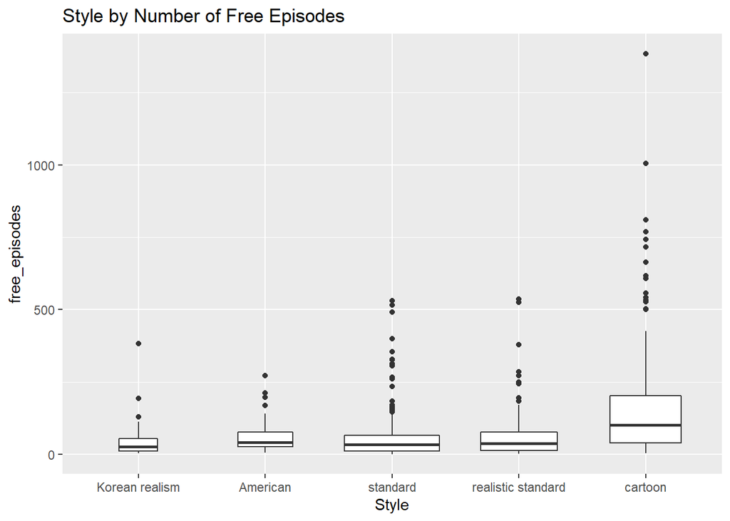

```r
ggplot(webtoons, aes(reorder(style, free_episodes), free_episodes)) +
  geom_boxplot(varwidth = TRUE) +
  labs(
    title = 'Style by Number of Free Episodes',
    x = 'Style'
  )
```

Again, the styles with the most departure from the standard styles—cartoon and American—stand out the most. The American style has a much lower potential ceiling than the rest in terms of free episodes, and the cartoon style has a higher median than every other style’s 75th percentiles.

Let’s see if we can make any other obvious distinctions between styles by comparing each genre’s composition.

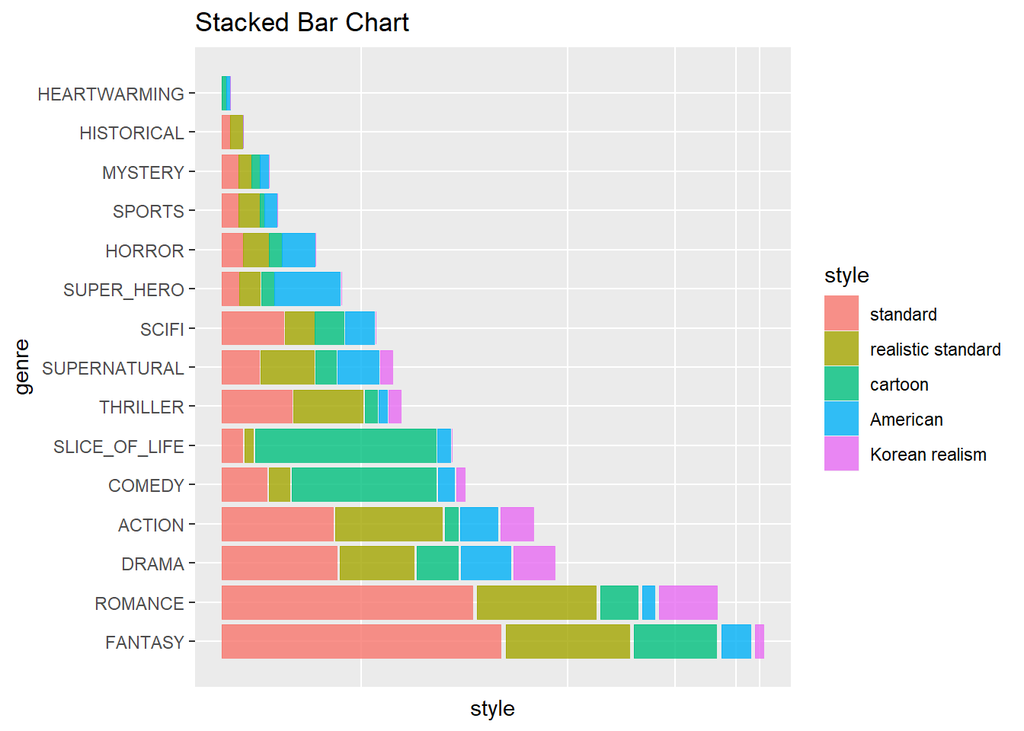

```r
webtoons %>%
  mutate(genre = forcats::fct_infreq(genre)) %>%
ggplot() +
  geom_mosaic(aes(x=product(style, genre), fill = style),
              divider=c('vspine', 'hbar')) +   coord_flip() +
  labs(x='genre', y = 'style', title = 'Stacked Bar Chart') + theme(axis.text.x = element_blank(),
axis.ticks.x = element_blank())
```

Surprisingly, while the American style makes up most of the superhero genre, the superhero genre does not appear to make up most of the American style comics.

We can also see that the bulk of the cartoon styles are in the slice of life and the comedy comics. Hence cartoon is the only style that overwhelmingly dominates any single genre.

Now that we’ve explored the data, here is an overview of the cleaned variables that we will be looking at:

*The list above is also available in the codebook.*

# Dummy coding

Quite a few of the variables are not numeric. Now that we’ve explored the data, we will now unpack the categorical variables into more specific ones.

Let’s parse `status`, `original_platform`, `genre`, and the days of the week variables into boolean columns.

- `status`

```r
webtoons <- webtoons %>%
  mutate(n = 1) %>%
  pivot_wider(names_from = status, values_from = n, values_fill = list(n = 0))
```

- `original_platform`

```r
webtoons <- webtoons %>%
  mutate(n = 1) %>%
  pivot_wider(names_from = original_platform, values_from = n, values_fill = list(n = 0))
```

- `genre`

```r
webtoons <- webtoons %>%
  mutate(n = 1) %>%
  pivot_wider(names_from = genre, values_from = n, values_fill = list(n = 0))

# Lowercase all column names
names(webtoons) <- tolower(names(webtoons))
```

- days of the week

```r
webtoons <- cSplit_e(webtoons, 'weekdays', sep = ',', mode = 'binary',
         type = 'character', fill = 0, drop = TRUE)

# renaming
colnames(webtoons)[colnames(webtoons) == 'weekdays_SUNDAY'] <- 'sunday'
colnames(webtoons)[colnames(webtoons) == 'weekdays_MONDAY'] <- 'monday'
colnames(webtoons)[colnames(webtoons) == 'weekdays_TUESDAY'] <- 'tuesday'
colnames(webtoons)[colnames(webtoons) == 'weekdays_WEDNESDAY'] <- 'wednesday'
colnames(webtoons)[colnames(webtoons) == 'weekdays_THURSDAY'] <- 'thursday'
colnames(webtoons)[colnames(webtoons) == 'weekdays_FRIDAY'] <- 'friday'
colnames(webtoons)[colnames(webtoons) == 'weekdays_SATURDAY'] <- 'saturday'
```

- `daily_pass`

```r
webtoons$daily_pass <- ifelse(webtoons$daily_pass == TRUE, 1, 0)
```

# Factors

Now we will convert our categorial variables into factors.

- `style` and `daily_pass`

```r
webtoons$style <- as.factor(webtoons$style)
webtoons$daily_pass <- as.factor(webtoons$daily_pass)
```

- platforms

```r
webtoons$english <- as.factor(webtoons$english)
webtoons$korean <- as.factor(webtoons$korean)
webtoons$japanese <- as.factor(webtoons$japanese)
webtoons$indonesian <- as.factor(webtoons$indonesian)
```

- genres

```r
webtoons$action <- as.factor(webtoons$action)
webtoons$comedy <- as.factor(webtoons$comedy)
webtoons$drama <- as.factor(webtoons$drama)
webtoons$fantasy <- as.factor(webtoons$fantasy)
webtoons$heartwarming <- as.factor(webtoons$heartwarming)
webtoons$historical <- as.factor(webtoons$historical)
webtoons$horror <- as.factor(webtoons$horror)
webtoons$mystery <- as.factor(webtoons$mystery)
webtoons$romance <- as.factor(webtoons$romance)
webtoons$slice_of_life <- as.factor(webtoons$slice_of_life)
webtoons$scifi <- as.factor(webtoons$scifi)
webtoons$sports <- as.factor(webtoons$sports)
webtoons$super_hero <- as.factor(webtoons$super_hero)
webtoons$supernatural <- as.factor(webtoons$supernatural)
webtoons$thriller <- as.factor(webtoons$thriller)
```

- statuses

```r
webtoons$ongoing <- as.factor(webtoons$ongoing)
webtoons$completed <- as.factor(webtoons$completed)
webtoons$hiatus <- as.factor(webtoons$hiatus)
```

- days of the week

```r
webtoons$monday <- as.factor(webtoons$monday)
webtoons$tuesday <- as.factor(webtoons$tuesday)
webtoons$tuesday <- as.factor(webtoons$tuesday)
webtoons$wednesday <- as.factor(webtoons$wednesday)
webtoons$thursday <- as.factor(webtoons$thursday)
webtoons$friday <- as.factor(webtoons$friday)
webtoons$saturday <- as.factor(webtoons$saturday)
webtoons$sunday <- as.factor(webtoons$sunday)
```

# Model setup

## Data Split

We will allocate 80% of the data to the training set and 20% to the testing set.

```r
set.seed(66)
w_split <- initial_split(webtoons, prop = 0.8, strata = 'style')
w_train <- training(w_split)
w_test <- testing(w_split)
```

```r
# Here I will check that the data are split in correct percentages.
dim(w_train)
```

```
## [1] 561  38
```

```r
dim(w_test)
```

```
## [1] 143  38
```

```r
dim(webtoons)
```

```
## [1] 704  38
```

## Folding data

Now we will perform v-fold cross validation with 10 folds, stratifying by `style`.

```r
w_folds <- vfold_cv(data = w_train, v = 10, strata = 'style')
```

## Recipe

Setting up recipe to predict `style` by dummy coding all nominal variables and by normalizing all predictors:

```r
w_recipe <- recipe(style ~ rating + views  + daily_pass + free_episodes  + likes + subscribers + synopsis_length + monday + tuesday + wednesday + thursday + friday + saturday + sunday + ongoing + completed + hiatus + english + korean + japanese + indonesian + action + comedy + drama + fantasy + heartwarming + historical + horror + mystery + romance + scifi + slice_of_life + sports + super_hero + supernatural + thriller,
                   data = w_train) %>%
  step_dummy(c(daily_pass, monday, tuesday, wednesday, thursday, friday, saturday, sunday, ongoing, completed, hiatus, english, korean, japanese, indonesian, action, comedy, drama, fantasy, heartwarming, historical, horror, mystery, romance, scifi, slice_of_life, sports, super_hero, supernatural, thriller)) %>%
  step_normalize(all_predictors())
```

# Modeling

I decided to run the following models thanks to my dataset being dominated by categorical variables:

- multinomial logistic regression
- random forest
- boosted trees
- decision tree
- nearest neighbors

### Multinomial logistic regression

We will tune `penalty` and `mixture`. Since our outcome is `style`, `mode` is set to `classification`.

```r
multinom_mod <- multinom_reg(penalty = tune(),
                        mixture = tune()) %>%
  set_engine('glmnet') %>%
  set_mode('classification')
```

Next, we combine the model and recipe into a workflow.

```r
multinom_wkflow = workflow() %>%
  add_model(multinom_mod) %>%
  add_recipe(w_recipe)
```

Now we’ll define the tuning grid and finally tune the model. We’ll select the best performing model based on the area under the ROC curve.

```r
multinom_grid = grid_regular(penalty(range = c(-5, 5)),
                       mixture(range = c(0, 1)),
                       levels = 10)

multinom_tune <- tune_grid(object = multinom_wkflow,
                        resamples = w_folds,
                        grid = multinom_grid)
result_multinom <- multinom_tune %>%
  collect_metrics() %>%
  arrange(desc(mean)) %>%
  filter(row_number()==1)
```

```r
multinom_best <- multinom_tune %>%
  select_best(metric = 'roc_auc')

final_multinom_workflow <- multinom_wkflow %>%
                       finalize_workflow(multinom_best)

multinom_wf_fit <- final_multinom_workflow %>%
               fit(data = w_train)

m_tree_fit <- multinom_wf_fit %>%
            pull_workflow_fit()


m_tree_last_fit <- final_multinom_workflow %>%
                 last_fit(w_split)
m_tree_predictions <- m_tree_last_fit %>% collect_predictions()

multinom_acc <- augment(
  multinom_wf_fit, new_data = w_train) %>%
  accuracy(truth = style, estimate = .pred_class)

multinom_acc
```

| .metric | .estimator | .estimate |
| --- | --- | --- |
| accuracy | multiclass | 0.5597148 |

```r
result_multinom
```

| penalty | mixture | .metric | .estimator | mean | n | std_err | .config |
| --- | --- | --- | --- | --- | --- | --- | --- |
| 0.02154435 | 0.7777778 | roc_auc | hand_till | 0.778151 | 10 | 0.007489473 | Preprocessor1_Model074 |

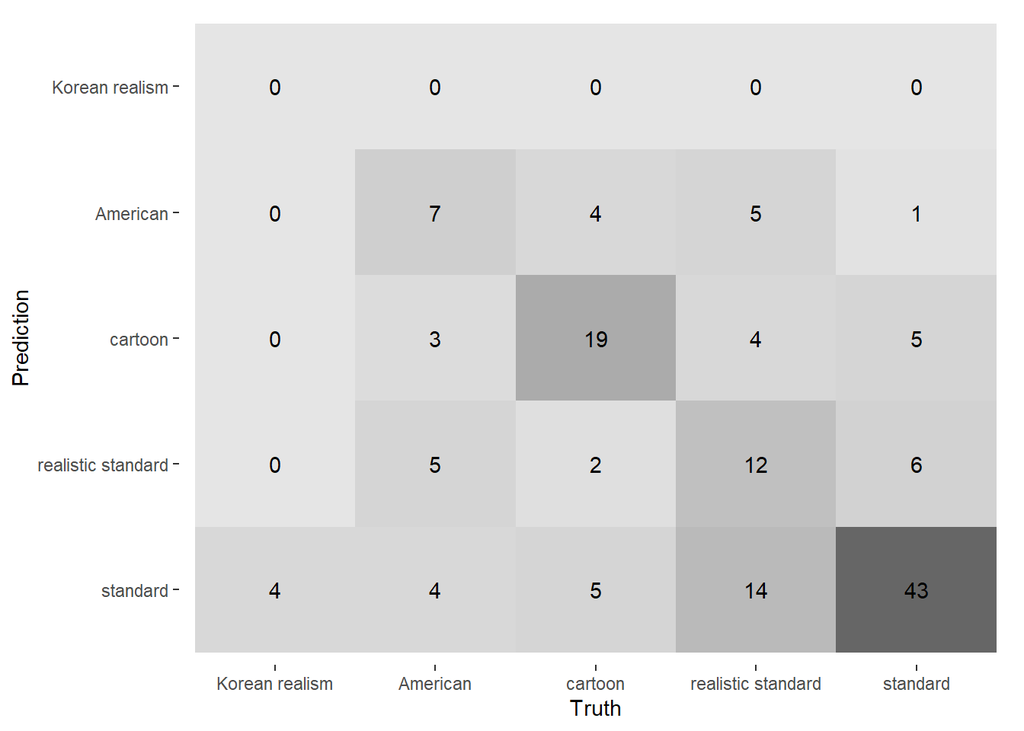

```r
conf_mat(m_tree_predictions, truth = style, estimate = .pred_class) %>%   autoplot(type = "heatmap") +
  scale_x_discrete(limits = rev) +
  scale_y_discrete(limits = rev)
```

78.2% of the standard, 34.3% of the realistic standard, 63.3% of the cartoon, and 36.8% of the American styles were predicted correctly.

### Random forest

```r
rf_mod <-
  rand_forest(min_n = tune(), mtry = tune()) %>%
  set_mode('classification') %>%
  set_engine('randomForest')

rf_wkflow <- workflow() %>%
  add_model(rf_mod) %>%
  add_recipe(w_recipe)

rf_grid <- grid_regular(min_n(),
                        mtry(range = c(1, 35)),
                        levels = 3)

tune_rf <- rf_wkflow %>%
  tune_grid(resamples = w_folds,
    grid = rf_grid)

# save(tune_rf, rf_wkflow,
#      file='./data/tuned_models/tune_rf.rda')

# load(file='./data/tuned_models/tune_rf.rda')

result_rf <- tune_rf %>%
  collect_metrics() %>%
  arrange(desc(mean)) %>%
  filter(row_number()==1)

result_rf
```

| mtry | min_n | .metric | .estimator | mean | n | std_err | .config |
| --- | --- | --- | --- | --- | --- | --- | --- |
| 18 | 21 | roc_auc | hand_till | 0.7655499 | 10 | 0.009248497 | Preprocessor1_Model5 |

0.77 is just a smidge lower than the last model’s 0.78, but the random forest has a higher standard error. Our multinomial model is the best so far.

### Boosted trees

Here we specify the tuning parameter `tree` and set the engine to `xgboost` before storing the recipe in a workflow:

```r
boost_mod <- boost_tree(trees = tune()) %>%
  set_engine('xgboost') %>%
  set_mode('classification')

boost_wkflow <- workflow() %>%
  add_model(boost_mod) %>%
  add_recipe(w_recipe)
```

Creating the tuning grid and then tuning:

```r
boost_grid <- grid_regular(trees(c(100, 1000)),
                           levels = 5)

tune_boost <- tune_grid(
  boost_wkflow,
  resamples = w_folds,
  grid = boost_grid
)

# save(tune_boost, boost_wkflow, file='./data/tuned_models/tune_boost.rda')
```

```r
# load(file='./data/tuned_models/tune_boost.rda')
result_boost <- tune_boost %>%
  collect_metrics() %>%
  arrange(desc(mean)) %>%
  filter(row_number()==1)

result_boost
```

| trees | .metric | .estimator | mean | n | std_err | .config |
| --- | --- | --- | --- | --- | --- | --- |
| 100 | roc_auc | hand_till | 0.7299665 | 10 | 0.01432919 | Preprocessor1_Model1 |

Still, the multinomial model is the best.

### Decision tree

We will now prepare to fit the decision tree model in a similar fashion.

Putting together the recipe, dummy coding the nominal variables, and normalizing all predictors:

```r
dt_recipe <- recipe(style ~ rating + views  + daily_pass + free_episodes  + likes + subscribers + synopsis_length + monday + tuesday + wednesday + thursday + friday + saturday + sunday + ongoing + completed + hiatus + english + korean + indonesian + action + comedy + drama + fantasy + heartwarming + historical + horror + mystery + romance + scifi + slice_of_life + sports + super_hero + supernatural + thriller,
                   data = w_train) %>%
  step_dummy(c(daily_pass, monday, tuesday, wednesday, thursday, friday, saturday, sunday, ongoing, completed, hiatus, english, korean, indonesian, action, comedy, drama, fantasy, heartwarming, historical, horror, mystery, romance, scifi, slice_of_life, sports, super_hero, supernatural, thriller)) %>%
  step_normalize(all_predictors())
```

Setting up the model, the workflow, and the tuning grid:

```r
dt_mod <- decision_tree(
  cost_complexity = tune(),
  tree_depth = tune(), min_n = tune()) %>%
  set_engine('rpart') %>%
  set_mode('classification')

dt_wkflow <- workflow() %>%
                 add_model(dt_mod) %>%
                 add_recipe(w_recipe)

dt_grid <- grid_regular(cost_complexity(),
                          tree_depth(),
                          min_n(),
                          levels = 3)
```

Finally, we fit the model:

```r
tune_dt <- dt_wkflow %>%
               tune_grid(resamples = w_folds,
                         grid = dt_grid)
tune_dt %>% show_best('roc_auc')
```

| cost_complexity | tree_depth | min_n | .metric | .estimator | mean | n | std_err | .config |
| --- | --- | --- | --- | --- | --- | --- | --- | --- |
| 1.000000e-10 | 15 | 40 | roc_auc | hand_till | 0.7309693 | 10 | 0.009726962 | Preprocessor1_Model25 |
| 3.162278e-06 | 15 | 40 | roc_auc | hand_till | 0.7309693 | 10 | 0.009726962 | Preprocessor1_Model26 |
| 1.000000e-10 | 8 | 40 | roc_auc | hand_till | 0.7302869 | 10 | 0.009411148 | Preprocessor1_Model22 |
| 3.162278e-06 | 8 | 40 | roc_auc | hand_till | 0.7302869 | 10 | 0.009411148 | Preprocessor1_Model23 |
| 1.000000e-10 | 8 | 21 | roc_auc | hand_till | 0.7167259 | 10 | 0.009465195 | Preprocessor1_Model13 |

Here’s a look at the decision tree.

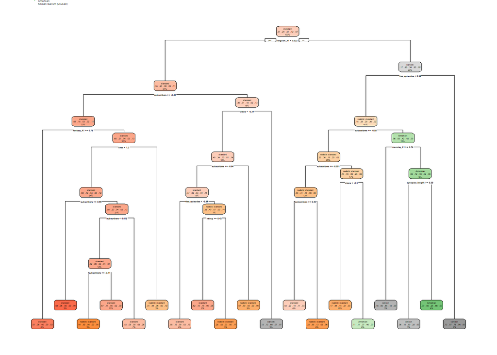

```r
dt_best <- tune_dt %>%
  select_best(metric = 'roc_auc')
final_dt_workflow <- dt_wkflow %>%
                       finalize_workflow(dt_best)

dt_wf_fit <- final_dt_workflow %>%
               fit(data = w_train)

tree_fit <- dt_wf_fit %>%
            pull_workflow_fit()

rpart.plot(tree_fit$fit, roundint = FALSE)
```

On one end are the American and cartoon styles; on the other, the standard and realistic standard styles.

```r
tree_last_fit <- final_dt_workflow %>%
                 last_fit(w_split)


tree_predictions <- tree_last_fit %>% collect_predictions()

result_dt <- arrange(
  collect_metrics(tune_dt),
  desc(mean)) %>%
  filter(row_number()==1)
result_dt
```

| cost_complexity | tree_depth | min_n | .metric | .estimator | mean | n | std_err | .config |
| --- | --- | --- | --- | --- | --- | --- | --- | --- |
| 1e-10 | 15 | 40 | roc_auc | hand_till | 0.7309693 | 10 | 0.009726962 | Preprocessor1_Model25 |

The multinomial model still reigns. Out of curiosity, let’s see what the model predicted.

A heatmap of our results shows that the decision tree had quite a bit of trouble separating the standard style from the Korean realism style with the given predictors. The model failed to correctly recognize *any* of the Korean realism-style webtoons, for that matter.

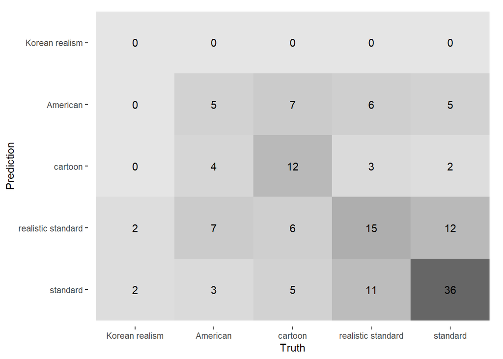

```r
conf_mat(tree_predictions, truth = style, estimate = .pred_class) %>%   autoplot(type = "heatmap") +
  scale_x_discrete(limits = rev) +
  scale_y_discrete(limits = rev)
```

65.5% of the standard, 42.9% of the realistic standard, 40.0% of the cartoon, and 26.3% of the American styles were predicted correctly.

### Nearest Neighbors

For our last model, let’s run cross fold validation on the nearest neighbors model. Again, let’s create the model and set up the workflow.

```r
knn_mod <-
  nearest_neighbor(
    neighbors = tune(),
    mode = 'classification') %>%
  set_engine('kknn')

knn_wkflow <- workflow() %>%
  add_model(knn_mod) %>%
  add_recipe(w_recipe)
```

Setting up the tuning grid:

```r
knn_params <- parameters(knn_mod)

knn_grid <- grid_regular(knn_params, levels = 2)
```

Tuning:

```r
tune_knn <- knn_wkflow %>%
  tune_grid(resamples = w_folds,
            grid = knn_grid)

# save(tune_knn, knn_wkflow, file = "data/tuned_models/tune_knn.rda")# load(file='./data/tuned_models/tune_knn.rda')
```

Below, we’ll see how the model performed.

```r
best_complexity <- select_best(tune_knn, metric = "roc_auc")

knn_final <- finalize_workflow(knn_wkflow, best_complexity)

knn_fit <- fit(knn_final,data = w_train)
augment(knn_fit, new_data = w_test) %>%
  accuracy(truth = style, estimate = .pred_class)
```

| .metric | .estimator | .estimate |
| --- | --- | --- |
| accuracy | multiclass | 0.4755245 |

```r
result_knn <-arrange(collect_metrics(tune_knn),
                     desc(mean)) %>%
  select(-.estimator, -.config) %>%
  filter(row_number()==1)

result_knn
```

| neighbors | .metric | mean | n | std_err |
| --- | --- | --- | --- | --- |
| 15 | roc_auc | 0.7216767 | 10 | 0.0157646 |

The nearest neighbors model still can’t beat the multinomial one. Let’s examine the heatmap to see if there are any notable differences.

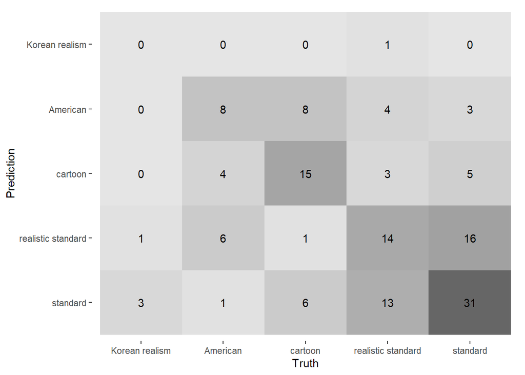

```r
augment(knn_fit, new_data = w_test) %>%
  conf_mat(truth = style, estimate = .pred_class) %>%
  autoplot(type = "heatmap")+
  scale_x_discrete(limits = rev) +
  scale_y_discrete(limits = rev)
```

We see a similar problem. KNN can’t decipher what makes a style Korean realism, but we do see one failed guess at a realistic standard style comic this time!

```r
result_lab <- c('multinom', 'rf', 'boost', 'dt', 'knn')

result_means <- c(result_multinom['mean'], result_rf['mean'], result_boost['mean'], result_dt['mean'], result_knn['mean'])

result_sd <- c(result_multinom['std_err'], result_rf['std_err'], result_boost['std_err'], result_dt['std_err'], result_knn['std_err'])

result_matrix <- matrix(c(result_means, result_sd), ncol = 2)

colnames(result_matrix) <- c('means', 'std_err')
rownames(result_matrix) <- result_lab

result_matrix
```

```
##          means     std_err
## multinom 0.778151  0.007489473
## rf       0.7655499 0.009248497
## boost    0.7299665 0.01432919
## dt       0.7309693 0.009726962
## knn      0.7216767 0.0157646
```

Overall, it looks like the multinomial model did the best.

# Evaluating the Best Model

Let’s fit our trained logistic model to the test set and see how we did!

```r
final_multinom_tune = multinom_tune %>%
  select_best("roc_auc")

final_multinom_wkflow = multinom_wkflow %>%
  finalize_workflow(final_multinom_tune)

final_multinom_fit = final_multinom_wkflow %>%
  fit(w_train)


predict_best = augment(final_multinom_fit, w_test)

final_accuracy <- accuracy(data=predict_best, truth=style,
        estimate=.pred_class)
final_accuracy
```

| .metric | .estimator | .estimate |
| --- | --- | --- |
| accuracy | multiclass | 0.5664336 |

```r
acc_lab <- c('test', 'train')

acc <- c(final_accuracy['.estimate'], multinom_acc['.estimate'])

acc_matrix <- matrix(acc)

colnames(acc_matrix) <- 'accuracy'
rownames(acc_matrix) <- acc_lab

acc_matrix
```

```
##       accuracy
## test  0.5664336
## train 0.5597148
```

The model actually performed slightly better on the testing set! Though, it’s possible this is just due to noise. Let’s take a closer look at what happened.

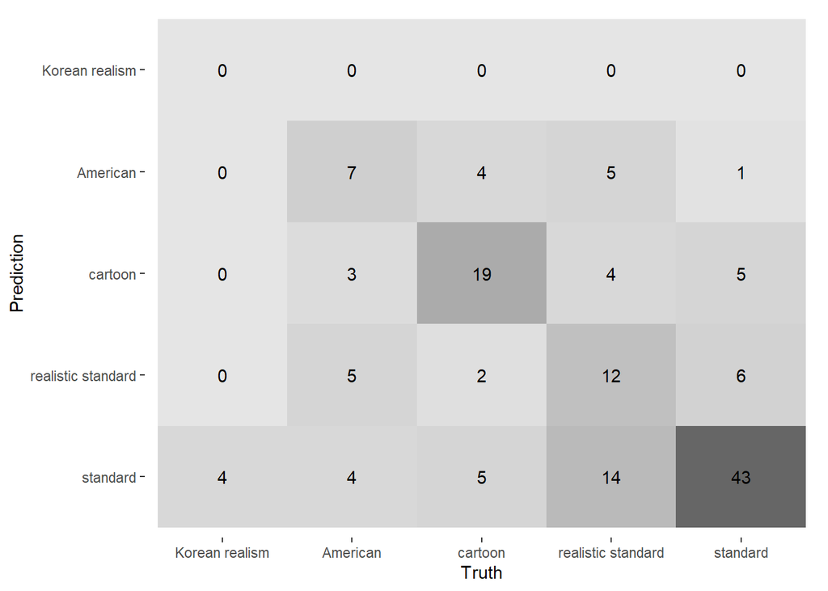

```r
conf_mat(predict_best, truth = style, estimate = .pred_class) %>%   autoplot(type = "heatmap") +
  scale_x_discrete(limits = rev) +
  scale_y_discrete(limits = rev)
```

Again, it looks like our model can’t distinguish the Korean realism style at all. I find it interesting that the only times it even tried to predict it, it incorrectly guessed the standard style.

```r
genre_lab <- c('standard', 'realistic standard', 'cartoon', 'American', 'Korean realism')

test_pred <- c(78.2, 34.3, 63.3, 36.8, 0.0)
train_pred <- c(65.5, 42.9, 40.0, 26.3, 0.0)

pred_matrix <- matrix(c(test_pred, train_pred), ncol = 2)
rownames(pred_matrix) <- genre_lab
colnames(pred_matrix) <- c('test (%)', 'train (%)')

pred_matrix
```

```
##                    test (%) train (%)
## standard               78.2      65.5
## realistic standard     34.3      42.9
## cartoon                63.3      40.0
## American               36.8      26.3
## Korean realism          0.0       0.0
```

Considering that I manually inputted every single style before I wrote the rest of this project, knowing what I do now, I might recategorize several webtoons. I would have liked to include more variables such as brush texture, author age, existence of author(s)’ social media, color palette, and panel length, but those are not available in Webtoons’ API and would thus require ungodly hours of simply gathering data. Nonetheless I am still impressed by how the model performed with the information it had.